[figure not shown]

# A Data Science Approach to Forecast Electricity Consumption in Australia Incorporating ENSO Data

**Team:** 5

**Session:** Hexamester 5, 2024

**Course Code:** ZZSC9020

**Author(s):**

- Eugene Ho (z5497345) Data and Technical Specialist
- Majuwana Kariyawasam (z5398970) Data Specialist and AI Engineer
- Tariq Khan (z5414837) Data Specialist and ML Engineer
- Tom Woodley (z5450185) Group Leader

**Date:** 05/10/2024

**Acknowledgements:**

- By far the greatest thanks must go to my supervisor for the guidance, care and support they provided.
- Thanks to Emily, Michelle, John and Alex for proofreading the document in the final stages of preparation.
- Thanks to Robert Taggart for allowing his thesis style to be copied.

# Abstract

[figure not shown]

# Introduction

Forecasting energy demand in the Australian market is crucial to maintaining a balanced and reliable electricity supply. With fluctuations in weather conditions and seasonal patterns, it is essential for energy producers and operators to predict demand accurately, allowing them to adjust outputs and bidding strategies effectively. The Australian Energy Market Operator (AEMO) plays a central role in producing forecasts over a variety of timescales, which help energy producers, grid operators, and businesses manage their operations to prevent both shortages and surpluses (Australian Energy Market Operator, 2022). These forecasts form the backbone of energy supply planning, and their accuracy directly impacts grid stability, pricing, and operational efficiency.

In Australia, weather conditions are a primary factor influencing energy demand. Temperature variations, in particular, are significant drivers. For example, during periods of extreme heat, there is a marked increase in electricity consumption due to higher usage of cooling systems such as air conditioners. Conversely, colder spells can lead to a surge in heating demand which affects electricity consumption. Anticipating demand on the monthly, and longer timescales is important for legacy (fossil fuel) producers of electricity as their agility to react to changes in demand is determined by usage in the order of the hourly scale and also by securing adequate fuel to produce the energy.

AEMO closely monitors energy demand in response to unexpected events—referred to as "Shock Events"—which could be caused by sudden weather changes or infrastructure failures, further complicating the demand landscape (Australian Energy Market Operator, 2022). These shock events are commonly associated with extreme weather events on the climactic scale. One macro-driver of weather in the Pacific Ocean is the El Niño-Southern Oscillation (ENSO). ENSO is a climate phenomenon that affects weather patterns across Australia, with its two main phases—El Niño and La Niña—having a significant influence on rainfall, temperature, and extreme weather events. El Niño is typically associated with hotter and drier conditions in eastern Australia, while La Niña brings cooler, wetter conditions. These variations in climate have a direct effect on energy demand, especially in highly populated states like New South Wales (NSW), where electricity consumption is sensitive to seasonal weather fluctuations. As climate science advances, it is becoming increasingly possible to incorporate ENSO data into energy forecasting models. Given ENSO’s role in driving large-scale weather changes, its inclusion in energy demand models is justified, particularly in regions like NSW, where climate variability can have profound effects on electricity consumption.

This project investigates whether the integration of ENSO phases into weather and population data and then modeled using common meachine learning libraries can produce models that are competetive with AEMO's own projections. This focus is particularly relevant for legacy energy producers, who need to plan ahead for fuel procurement and production ramp-ups, as they cannot adjust output as quickly as renewable energy sources such as solar or wind. ENSO phases provide a valuable indicator of seasonal climate trends and their inclusion could improve the ability of models to predict medium-term energy demand. In this project, the forecasting time scale is set to monthly intervals, as this aligns with the operational requirements of legacy energy producers while the granularity of the data remains at an hourly level to capture variations in demand at the dispatch cycle level (each dispatch cycle is half-hourly so mean values are used to give hourly results).

Off-the-shelf machine learning models such as Linear Models (LMs), Extreme Gradient Boosting (XGBoost), Random Forest Regressors and Multilayer Perceptrons (MLPs) are used to assess whether the inclusion of ENSO phases enhances the predictive power of weather-based models when compared against the provided AEMO predictions. These machine learning models have proven effective in handling large and complex datasets, identifying patterns in data and capturing non-linear relationships, all of which are critical when forecasting energy demand in a highly dynamic environment like an electricity market operating on robust infrastructure. Linear Models, while not as accurate as more sophisticated machine learning models are commonly used for predictions as their simplicity and easy interpretabiliy is useful when engaging non-technical stakeholders. However, as the complexity of weather data and demand patterns increase, more advanced techniques such as XGBoost and Random Forest become essential due to their ability to capture intricate relationships between weather variables and demand and not be limited by the assumptions of linearity and independence.

Incorporating ENSO phases as an additional predictor in these models represents a potential step forward in improving the accuracy of medium-term forecasts. The unique advantage of including ENSO lies in its ability to provide a longer-term view of climate patterns and the recent advent of reliable ENSO forecasting resulting in ENSO being useful as an explanatory variable in predictions. ENSO offers a broad seasonal perspective on climate which in turn allows for models that predict energy demand through secondary effects like temperature, wind and rainfall to improve accuracy. As an example: during an El Niño phase, energy producers in New South Wales might anticipate higher-than-average electricity demand due to prolonged periods of heat. ENSO also operates in a neutral phase or La Niña phase which drives lower temperatures and wetter conditions.

# Literature Review

Numerous studies in recent year have explored the relationship between weather conditions and energy demand. It has been shown that temperature is a key driver of energy consumption at all levels of monitoring (International Energy Agency, 2023). Temperature appears to be the greatest driving factor in energy consumption, when controlling for population (Eskeland and Mideksa, 2010). This is especially true for regions with extreme climates like NSW (Vu, Muttaqi and Agalgaonkar, 2015; Zhou et al., 2021). Research has also highlighted the importance of accounting for seasonal variations and extraordinary events in demand forecasting models (Albuquerque, Cajueiro and Rossi, 2022). The same research gives insight into the use of different modelling techniques for different time horizons. It is also of note that private (residential and commercial spaces) solar energy production are not captured by data published by AEMO due to the poor data surrounding private solar market penetration (Australian Photovoltaic Institute, 2024) and data capture for the weather-driver of solar energy production; solar irradiance does not have sufficient granularity to determine production quantity using direct methods (Mfetoum et al., 2024) which makes it a prime candidate for machine learning and deep learning models. It would therefore be worth pursuing a machine learning model for solar cell market penetration using similar techniques to those presented here. Many models rely on general linear models (Fan, MacGill and Sproul, 2017; Leung, 2022; Porteiro, Hernández-Callejo and Nesmachnow, 2022) which, while often accurate, struggle with higher-level interactions, seasonality and non-linear effects. GLMs are useful because of their simplicity and ease of communication to non-technical stakeholders. They are additionally, not time or resource-intensive and can be trained and deployed easily (Nooruldeen et al., 2023). Many such models, of which ARIMA (Fattah et al., 2018) and its derivatives: ARIMAX and SARIMA (Kumar Dubey et al., 2021; Bilgili and Pinar, 2023) are some of the most widely used because they have the advantage over other linear models of being able to deal with seasonal effects. The decision to use a linear model (scikit-learn’s LinearRegression) as a basis in this report is therefore taken from the perspective that monthly forecasts don’t experience the cyclic demand profile present in sub-daily and annual forecasts which can be observed in the Exploratory Data Analysis. Linear regression models have been used to great effect at forecasting demand in the Sydney region under different parameters (Fan, Macgill and Sproul, 2015; Fan, MacGill and Sproul, 2017) but with the core assumptions in linear modelling of non-collinearity and linear relationships between explanatory and response variables. Given the heatmap generated in the Exploratory Data Analysis that shows spurious linearity between variables, it is necessary to investigate further using more sophisticated machine learning models.

Machine learning models like Random Forest (Bedi and Toshniwal, 2019; Albuquerque, Cajueiro and Rossi, 2022; Vijendar Reddy et al., 2023) which is an ensemble method address non-linearities and seasonal influences effectively. Random Forest has an advantage over simpler models in that it is highly accurate and resistant to overfitting because it can handle non-linear model boundaries (AIML maintainers, no date). It is however, limited by the complexity of the model it generates being difficult to communicate or visualise as well as its inability to easily extrapolate outside the range of given data (Thompson, 2019) which would be a distinct disadvantage when taking into account the effects of increased population, climate change and residential power generation (like solar). More complex models such as Convolutional Neural Networks (Koprinska, Wu and Wang, 2018) and XGBoost (Extreme Gradient Boost)(Vijendar Reddy et al., 2023) have also been successful by handling seasonality, trends, and non-linearities well. Similarly to Random Forest, XGBoost also struggles with extrapolation outside the range of the training set (Mavuduru, 2020) but is faster and often more accurate. A simpler neural network approach is also to use a multilayer perceptron (MLP) which could possibly combine the advantages of being both computationally cheap and able to handle seasonality and non-linearity (Scikit Learn Maintainers, 2024b, 2024a) whilst noting that, in practice, MLP are used to feed forward into other models for energy forecasting (Afzal et al., 2023). The application of a hybrid approach when employing an MLP belies an assumption that they are not sufficient for energy demand forecasting on their own. Both Random Forest and XGBoost will form part of the basis for this investigation and will each be representative of ensemble classification and gradient boosting algorithms. They will be applied with linear regression model and MLP models that have been tuned to fit the dataset. By applying all four modelling approaches, a picture of accuracy versus complexity can be determined.

None of the studies used to determine appropriate models integrate macro-seasonal factors like ENSO, presenting a gap in current models. In the past two years, the ability to accurately predict when El Niño and La Niña will occur has dramatically improved (Liu et al., 2023), paving the way for a variety of statistics-based models to take advantage of this accurate forecasting. This work aims to expand on previous models by incorporating ENSO projections and population growth. A variety of off-the-shelf linear models and machine learning techniques (Random Forest, XGBoost and MLP) will be used to address this knowledge gap without considering hybrid models (Chreng, Lee and Tuy, 2022; Afzal et al., 2023).

An interesting further application, in addition to considering ARIMA, ARIMAX and SARIMA is to use a hybrid model approach which blends two models or uses the output of one to feed into the other to produce accurate forecasts (Fan and Hyndman, 2010; Vu, Muttaqi and Agalgaonkar, 2015; Chreng, Lee and Tuy, 2022; Afzal et al., 2023). Additionally, the advanced linear-based technique: long short-term memory (LSTM) is also used in energy forecasts (Kumar Dubey et al., 2021; Mahjoub et al., 2022; Bilgili and Pinar, 2023; Qureshi, Arbab and Rehman, 2024) for its ability to overcome the extrapolation shortcomings of decision tree and gradient boosting algorithms. Both these approaches are consistent with the state of the art and could be used to build on the foundation of this study where boilerplate models were tuned and applied to a novel dataset.

# Material and Methods

## Software

For the non-technical requirements of the project:

- Discord was used for instant messaging due to its easy integration with mobile and computing platforms.
- Microsoft Teams was used for video conferencing and file sharing as well as meeting with supervisors.
- Github was used for version control and collaboration on code.
- Microsoft Planner was used for task management and tracking.
- Microoft PowerPoint and OBS Studio were used for the final presentation and for recording the presentation.

## Description of the Data

Once the provided weather data was validated for consistency with the historical weather data that includes temperature, precipitation and humidity from BoM, superfluous data were dropped

Population growth data from New South Wales (produced by the Australian Buraeu of Statistics) was also collected and used in the models. Additionally, population forecasts until 2070 were obtained from the Australian Bureau of Statistics (ABS) and used to forecast energy demand in the future.

All data can be found in the Github repository under the data folder.

## Exploratory Data Analysis

Here we explore the data using histograms, scatter plots, and numerical summaries.

```python
#setting up the environment

#install the required packages if they are not already installed
%pip install pandas matplotlib numpy scikit-learn seaborn statsmodels > dev null
```

```python
import pandas as pd
import matplotlib.pyplot as plt
import seaborn as sns
import numpy as np
```

## Temperature

```python
df_temp = pd.read_csv(
    "../data/NSW/temperature_nsw.csv", names=["location", "datetime", "temp"], header=0
)
```

```python
df_temp.head()
```

|  | location | datetime | temp |
| --- | --- | --- | --- |
| 0 | Bankstown | 1/1/2010 0:00 | 23.1 |
| 1 | Bankstown | 1/1/2010 0:01 | 23.1 |
| 2 | Bankstown | 1/1/2010 0:30 | 22.9 |
| 3 | Bankstown | 1/1/2010 0:50 | 22.7 |
| 4 | Bankstown | 1/1/2010 1:00 | 22.6 |

```python
# Check for missing values
print("Number of missing value")
df_temp.isnull().sum()
```

```
Number of missing value
```

```
location    0
datetime    0
temp        0
dtype: int64
```

No missing value

```python
# Convert the datetime a datetime object
df_temp["datetime"] = pd.to_datetime(df_temp["datetime"], format="%d/%m/%Y %H:%M")
```

```python
df_temp.describe()
```

|  | temp |
| --- | --- |
| count | 220326.000000 |
| mean | 17.418827 |
| std | 5.849763 |
| min | -1.300000 |
| 25% | 13.400000 |
| 50% | 17.700000 |
| 75% | 21.300000 |
| max | 44.700000 |

from a glance, doesn't look like there is any outlier that needs to be removed from the data. We will use a boxplot to confirm this.

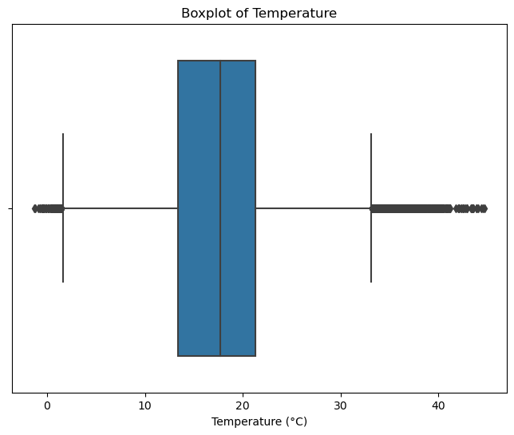

```python
# Box plot of temperature
plt.figure(figsize=(8, 6))
sns.boxplot(data=df_temp, x="temp")
plt.title("Boxplot of Temperature")
plt.xlabel("Temperature (°C)")
plt.show()
```

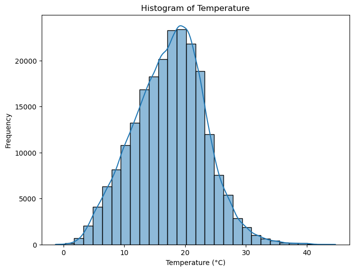

```python
# Histogram of temperature
plt.figure(figsize=(8, 6))
sns.histplot(df_temp["temp"], bins=30, kde=True)
plt.title("Histogram of Temperature")
plt.xlabel("Temperature (°C)")
plt.ylabel("Frequency")
plt.show()
```

Temperature seems relatively normally distributed

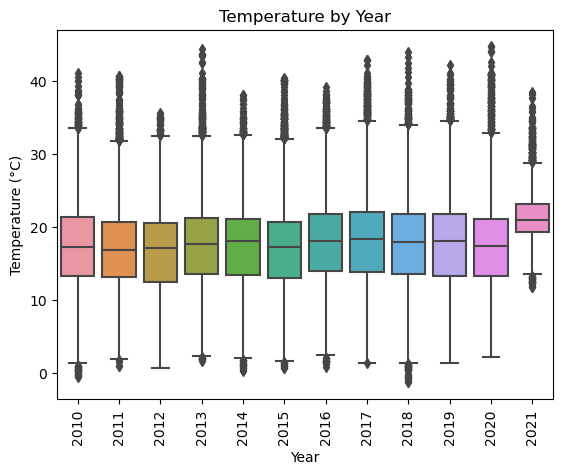

```python
# Box plot of each year's temperature
df_temp["year"] = df_temp["datetime"].dt.year
ax = sns.boxplot(data=df_temp, x="year", y="temp")
plt.title("Temperature by Year")
plt.xlabel("Year")
plt.ylabel("Temperature (°C)")
for item in ax.get_xticklabels():
    item.set_rotation(90)
plt.show()
```

```python
# Checking the latest entries of the data
df_temp.head(-1)
```

|  | location | datetime | temp | year |
| --- | --- | --- | --- | --- |
| 0 | Bankstown | 2010-01-01 00:00:00 | 23.1 | 2010 |
| 1 | Bankstown | 2010-01-01 00:01:00 | 23.1 | 2010 |
| 2 | Bankstown | 2010-01-01 00:30:00 | 22.9 | 2010 |
| 3 | Bankstown | 2010-01-01 00:50:00 | 22.7 | 2010 |
| 4 | Bankstown | 2010-01-01 01:00:00 | 22.6 | 2010 |
| ... | ... | ... | ... | ... |
| 220320 | Bankstown | 2021-03-17 22:30:00 | 19.5 | 2021 |
| 220321 | Bankstown | 2021-03-17 23:00:00 | 19.1 | 2021 |
| 220322 | Bankstown | 2021-03-17 23:20:00 | 19.0 | 2021 |
| 220323 | Bankstown | 2021-03-17 23:30:00 | 18.8 | 2021 |
| 220324 | Bankstown | 2021-03-17 23:34:00 | 18.8 | 2021 |

220325 rows × 4 columns

- Temperature seems very stable year to year, with a central range around 20°C
- Outliers (extreme high and low temperatures) are consistently present every year, indicating occasional temperature extremes
- 2021 only has data up to March, which most likely is the reason for its different distribution compared to previous years. Prehaps we should remove the 2021 data

We will only use data up to 2020 for the hourly analysis to avoid altering the overall result

```python
up_to_2020 = df_temp[df_temp["year"] < 2021]
up_to_2020.head()
```

|  | location | datetime | temp | year |
| --- | --- | --- | --- | --- |
| 0 | Bankstown | 2010-01-01 00:00:00 | 23.1 | 2010 |
| 1 | Bankstown | 2010-01-01 00:01:00 | 23.1 | 2010 |
| 2 | Bankstown | 2010-01-01 00:30:00 | 22.9 | 2010 |
| 3 | Bankstown | 2010-01-01 00:50:00 | 22.7 | 2010 |
| 4 | Bankstown | 2010-01-01 01:00:00 | 22.6 | 2010 |

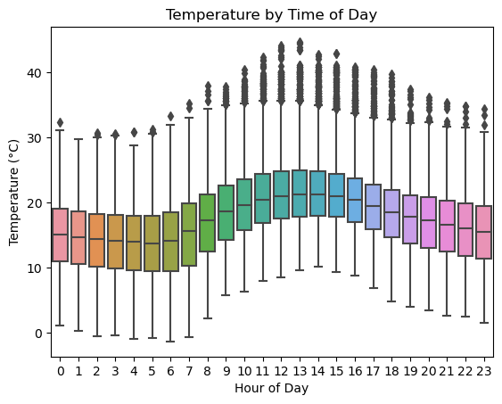

```python
up_to_2020["hour"] = up_to_2020["datetime"].dt.hour
ax = sns.boxplot(data=up_to_2020, x="hour", y="temp")
plt.title("Temperature by Time of Day")
plt.xlabel("Hour of Day")
plt.ylabel("Temperature (°C)")
plt.show()
```

## Demand

```python
df_demand = pd.read_csv(
    "../data/NSW/totaldemand_nsw.csv", names=["datetime", "demand"], header=0
)
```

```python
df_demand.head()
```

|  | datetime | demand |
| --- | --- | --- |
| 0 | 1/1/2010 0:00 | 8038.00 |
| 1 | 1/1/2010 0:30 | 7809.31 |
| 2 | 1/1/2010 1:00 | 7483.69 |
| 3 | 1/1/2010 1:30 | 7117.23 |
| 4 | 1/1/2010 2:00 | 6812.03 |

```python
# Convert the datetime a datetime object
df_demand["datetime"] = pd.to_datetime(df_demand["datetime"], format="%d/%m/%Y %H:%M")
```

```python
df_demand.head()
```

|  | datetime | demand |
| --- | --- | --- |
| 0 | 2010-01-01 00:00:00 | 8038.00 |
| 1 | 2010-01-01 00:30:00 | 7809.31 |
| 2 | 2010-01-01 01:00:00 | 7483.69 |
| 3 | 2010-01-01 01:30:00 | 7117.23 |
| 4 | 2010-01-01 02:00:00 | 6812.03 |

```python
# Check for missing values
df_demand.isnull().sum()
```

```
datetime    0
demand      0
dtype: int64
```

```python
df_demand.describe()
```

|  | demand |
| --- | --- |
| count | 196513.000000 |
| mean | 8113.145859 |
| std | 1299.532774 |
| min | 5074.630000 |
| 25% | 7150.070000 |
| 50% | 8053.230000 |
| 75% | 8958.550000 |
| max | 14579.860000 |

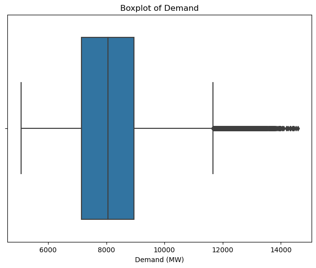

```python
plt.figure(figsize=(8, 6))
sns.boxplot(data=df_demand, x="demand")
plt.title("Boxplot of Demand")
plt.xlabel("Demand (MW)")
plt.show()
```

distribution of demand seems somewhat right skewed, while most demand values lie below 12,000 MW, a small number of instances exhibit higher demand levels. In general, it seems that demand usually hovers around 8,000 MW but can occasionally spike.

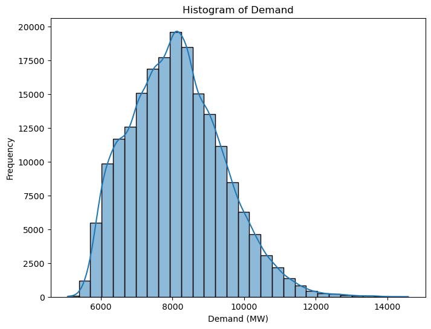

```python
plt.figure(figsize=(8, 6))
sns.histplot(df_demand["demand"], bins=30, kde=True)
plt.title("Histogram of Demand")
plt.xlabel("Demand (MW)")
plt.ylabel("Frequency")
plt.show()
```

The histogram comfirms the right-skewness nature of the demand data. The long right tail indicates that the occasional spike has demands that are significantly higher than the average. Electricity grid planners may need to account for occasional high demand spikes evem if they occur less frequently.

Let's look at the demand of each year

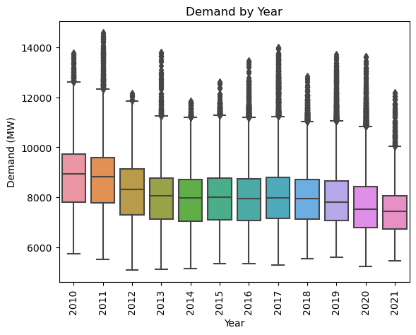

```python
df_demand["year"] = df_demand["datetime"].dt.year
ax = sns.boxplot(data=df_demand, x="year", y="demand")
plt.title("Demand by Year")
plt.xlabel("Year")
plt.ylabel("Demand (MW)")
for item in ax.get_xticklabels():
    item.set_rotation(90)
plt.show()
```

```python
df_demand.head(-1)
```

|  | datetime | demand | year |
| --- | --- | --- | --- |
| 0 | 2010-01-01 00:00:00 | 8038.00 | 2010 |
| 1 | 2010-01-01 00:30:00 | 7809.31 | 2010 |
| 2 | 2010-01-01 01:00:00 | 7483.69 | 2010 |
| 3 | 2010-01-01 01:30:00 | 7117.23 | 2010 |
| 4 | 2010-01-01 02:00:00 | 6812.03 | 2010 |
| ... | ... | ... | ... |
| 196507 | 2021-03-17 21:30:00 | 7503.12 | 2021 |
| 196508 | 2021-03-17 22:00:00 | 7419.77 | 2021 |
| 196509 | 2021-03-17 22:30:00 | 7417.91 | 2021 |
| 196510 | 2021-03-17 23:00:00 | 7287.32 | 2021 |
| 196511 | 2021-03-17 23:30:00 | 7172.39 | 2021 |

196512 rows × 3 columns

Similar to the Temperature data, the Demand data only goes up to March 2021, therefore the distribution for Year 2021 is most likely affected by the incomplete yearly data.

There may be a downward trend but too difficult to tell just from this

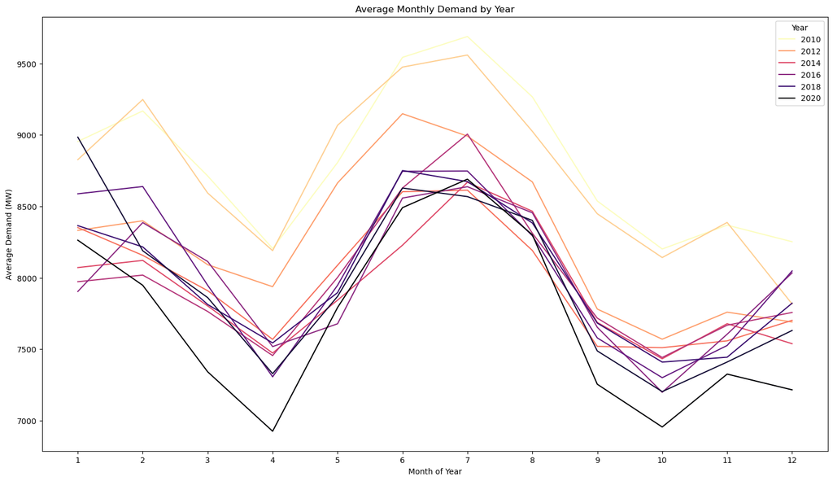

```python
plt.figure(figsize=(18, 10))
df_demand["month"] = df_demand["datetime"].dt.month
sns.lineplot(
    data=df_demand[(df_demand["year"] >= 2010) & (df_demand["year"] < 2021)],
    x="month",
    y="demand",
    hue="year",
    errorbar=None,
    palette="magma_r",
)

plt.title("Average Monthly Demand by Year")
plt.xlabel("Month of Year")
plt.ylabel("Average Demand (MW)")
plt.xticks(range(1, 13))
plt.legend(title="Year", bbox_to_anchor=(1, 1))
plt.show()
```

Let's look at the demand throughout the day

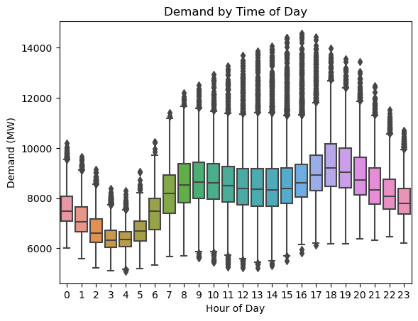

```python
df_demand["hour"] = df_demand["datetime"].dt.hour

# Only using data up to 2020
ax = sns.boxplot(data=df_demand[df_demand["year"] < 2021], x="hour", y="demand")
plt.title("Demand by Time of Day")
plt.xlabel("Hour of Day")
plt.ylabel("Demand (MW)")
plt.show()
```

Judging from the graphs, we may assume that Demand and temperature could be correlated

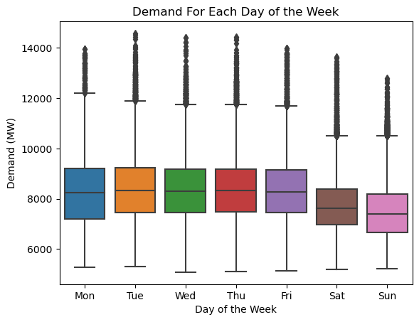

```python
df_demand["dayofweek"] = df_demand["datetime"].dt.weekday

# Only using data up to 2020
ax = sns.boxplot(data=df_demand[df_demand["year"] < 2021], x="dayofweek", y="demand")
plt.xticks(
    ticks=[0, 1, 2, 3, 4, 5, 6],
    labels=["Mon", "Tue", "Wed", "Thu", "Fri", "Sat", "Sun"],
)
plt.title("Demand For Each Day of the Week")
plt.xlabel("Day of the Week")
plt.ylabel("Demand (MW)")
plt.show()
```

interestingly, demand remains constant during weekdays but drops significantly during the weekends.

```python
df_merge = df_demand.merge(df_temp, on="datetime", how="left")
df_merge.head()
```

|  | datetime | demand | year_x | month | hour | dayofweek | location | temp | year_y |
| --- | --- | --- | --- | --- | --- | --- | --- | --- | --- |
| 0 | 2010-01-01 00:00:00 | 8038.00 | 2010 | 1 | 0 | 4 | Bankstown | 23.1 | 2010.0 |
| 1 | 2010-01-01 00:30:00 | 7809.31 | 2010 | 1 | 0 | 4 | Bankstown | 22.9 | 2010.0 |
| 2 | 2010-01-01 01:00:00 | 7483.69 | 2010 | 1 | 1 | 4 | Bankstown | 22.6 | 2010.0 |
| 3 | 2010-01-01 01:30:00 | 7117.23 | 2010 | 1 | 1 | 4 | Bankstown | 22.5 | 2010.0 |
| 4 | 2010-01-01 02:00:00 | 6812.03 | 2010 | 1 | 2 | 4 | Bankstown | 22.5 | 2010.0 |

```python
df_merge.drop(columns=["location", "year_y"], inplace=True)
df_merge.rename(columns={"year_x": "year"}, inplace=True)
df_merge.head()
```

|  | datetime | demand | year | month | hour | dayofweek | temp |
| --- | --- | --- | --- | --- | --- | --- | --- |
| 0 | 2010-01-01 00:00:00 | 8038.00 | 2010 | 1 | 0 | 4 | 23.1 |
| 1 | 2010-01-01 00:30:00 | 7809.31 | 2010 | 1 | 0 | 4 | 22.9 |
| 2 | 2010-01-01 01:00:00 | 7483.69 | 2010 | 1 | 1 | 4 | 22.6 |
| 3 | 2010-01-01 01:30:00 | 7117.23 | 2010 | 1 | 1 | 4 | 22.5 |
| 4 | 2010-01-01 02:00:00 | 6812.03 | 2010 | 1 | 2 | 4 | 22.5 |

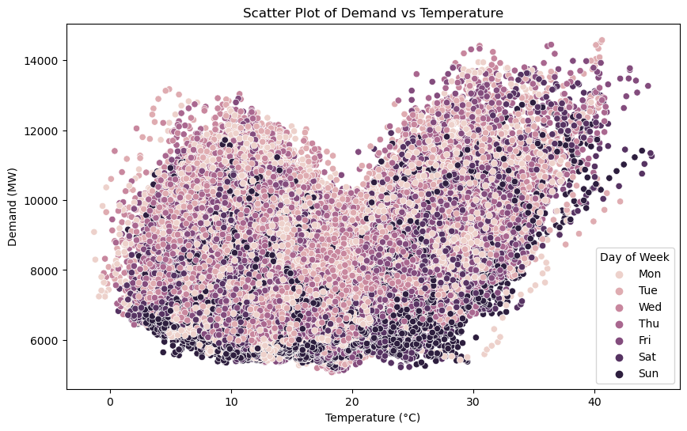

```python
plt.figure(figsize=(10, 6))
scatter = sns.scatterplot(x="temp", y="demand", hue="dayofweek", data=df_merge)

plt.xlabel("Temperature (°C)")
plt.ylabel("Demand (MW)")
plt.title("Scatter Plot of Demand vs Temperature")

# Customizing the legend labels
day_labels = ["Mon", "Tue", "Wed", "Thu", "Fri", "Sat", "Sun"]
handles, _ = scatter.get_legend_handles_labels()
plt.legend(handles, day_labels, title="Day of Week")

plt.show()
```

The variation in demand across different days suggests that specific days may have different consumption patterns, potentially due to workweek versus weekend differences.

Let's look at the average demand and temperature to confirm this.

```python
df_merge["date"] = df_merge["datetime"].dt.date
df_merge["daily_avg_demand"] = df_merge.groupby("date")["demand"].transform("mean")
df_merge["daily_avg_temp"] = df_merge.groupby("date")["temp"].transform("mean")
df_merge.head()
```

|  | datetime | demand | year | month | hour | dayofweek | temp | date | daily_avg_demand | daily_avg_temp |
| --- | --- | --- | --- | --- | --- | --- | --- | --- | --- | --- |
| 0 | 2010-01-01 00:00:00 | 8038.00 | 2010 | 1 | 0 | 4 | 23.1 | 2010-01-01 | 7801.352917 | 25.185417 |
| 1 | 2010-01-01 00:30:00 | 7809.31 | 2010 | 1 | 0 | 4 | 22.9 | 2010-01-01 | 7801.352917 | 25.185417 |
| 2 | 2010-01-01 01:00:00 | 7483.69 | 2010 | 1 | 1 | 4 | 22.6 | 2010-01-01 | 7801.352917 | 25.185417 |
| 3 | 2010-01-01 01:30:00 | 7117.23 | 2010 | 1 | 1 | 4 | 22.5 | 2010-01-01 | 7801.352917 | 25.185417 |
| 4 | 2010-01-01 02:00:00 | 6812.03 | 2010 | 1 | 2 | 4 | 22.5 | 2010-01-01 | 7801.352917 | 25.185417 |

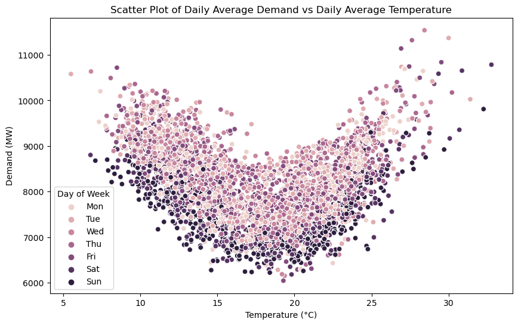

```python
plt.figure(figsize=(10, 6))
scatter = sns.scatterplot(
    x="daily_avg_temp", y="daily_avg_demand", hue="dayofweek", data=df_merge
)

plt.xlabel("Temperature (°C)")
plt.ylabel("Demand (MW)")
plt.title("Scatter Plot of Daily Average Demand vs Daily Average Temperature")

# Customizing the legend labels
day_labels = ["Mon", "Tue", "Wed", "Thu", "Fri", "Sat", "Sun"]
handles, _ = scatter.get_legend_handles_labels()
plt.legend(handles, day_labels, title="Day of Week")

plt.show()
```

We can see a much clearer pattern of weekends having much lower demand than weekdays. Day of the week very likely to have correlation to demand

Lets look at the seasonal impact on the demand

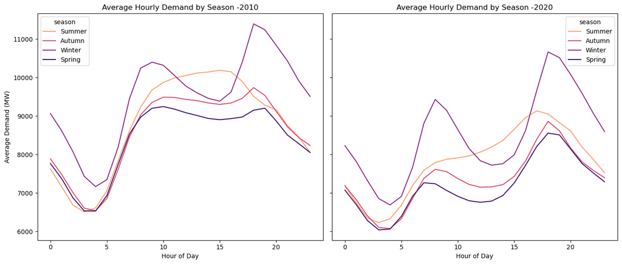

```python
# Adding a column for season
def season(month):
    if month in [12, 1, 2]:
        return "Summer"
    elif month in [3, 4, 5]:
        return "Autumn"
    elif month in [6, 7, 8]:
        return "Winter"
    elif month in [9, 10, 11]:
        return "Spring"


df_merge["month"] = df_merge["datetime"].dt.month
df_merge["season"] = df_merge["month"].apply(season)


# Plot 2010 and 2020 in the same figure
fig, axes = plt.subplots(1, 2, figsize=(14, 6), sharey=True)

# 2010
sns.lineplot(
    data=df_merge[df_merge["year"] == 2010],
    x="hour",
    y="demand",
    hue="season",
    ax=axes[0],
    errorbar=None,
    palette="magma_r",
)
axes[0].set_title("Average Hourly Demand by Season -2010")
axes[0].set_xlabel("Hour of Day")
axes[0].set_ylabel("Average Demand (MW)")

# 2020
sns.lineplot(
    data=df_merge[df_merge["year"] == 2020],
    x="hour",
    y="demand",
    hue="season",
    ax=axes[1],
    errorbar=None,
    palette="magma_r",
)
axes[1].set_title("Average Hourly Demand by Season -2020")
axes[1].set_xlabel("Hour of Day")
axes[1].set_ylabel("Average Demand (MW)")

plt.tight_layout()
plt.show()
```

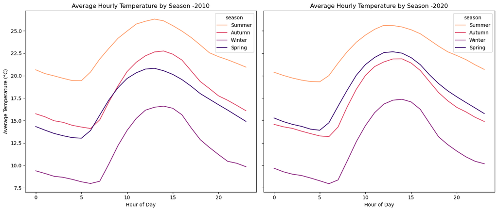

```python
# Plot 2010 and 2020 in the same figure
fig, axes = plt.subplots(1, 2, figsize=(14, 6), sharey=True)

# 2010
sns.lineplot(
    data=df_merge[df_merge["year"] == 2010],
    x="hour",
    y="temp",
    hue="season",
    ax=axes[0],
    errorbar=None,
    palette="magma_r",
)
axes[0].set_title("Average Hourly Temperature by Season -2010")
axes[0].set_xlabel("Hour of Day")
axes[0].set_ylabel("Average Temperature (°C)")

# 2020
sns.lineplot(
    data=df_merge[df_merge["year"] == 2020],
    x="hour",
    y="temp",
    hue="season",
    ax=axes[1],
    errorbar=None,
    palette="magma_r",
)
axes[1].set_title("Average Hourly Temperature by Season -2020")
axes[1].set_xlabel("Hour of Day")
axes[1].set_ylabel("Average Temperature (°C)")

plt.tight_layout()
plt.show()
```

## Population

```python
df_pop = pd.read_excel(
    "../data/Population/Population his.xlsx", sheet_name="Table 2", skiprows=4
)
```

```python
df_pop.head()
```

|  | Sex | State/Territory | 1901 | 1902 | 1903 | 1904 | 1905 | 1906 | 1907 | 1908 | ... | 2012 | 2013 | 2014 | 2015 | 2016 | 2017 | 2018 | 2019 | 2020 | 2021 |
| --- | --- | --- | --- | --- | --- | --- | --- | --- | --- | --- | --- | --- | --- | --- | --- | --- | --- | --- | --- | --- | --- |
| 0 | Male | NSW | 713414.0 | 728613.0 | 742240.0 | 756401.0 | 773677.0 | 791555.0 | 813030.0 | 826749.0 | ... | 3626400.0 | 3674410.0 | 3724215.0 | 3776574.0 | 3833807.0 | 3896830.0 | 3950763.0 | 3999452.0 | 4030710.0 | 4025393.0 |
| 1 | Male | Vic. | 604272.0 | 603923.0 | 600082.0 | 596203.0 | 595460.0 | 597378.0 | 602736.0 | 606736.0 | ... | 2796315.0 | 2856419.0 | 2915277.0 | 2977200.0 | 3051056.0 | 3116504.0 | 3178223.0 | 3236531.0 | 3273674.0 | 3237594.0 |
| 2 | Male | Qld | 279644.0 | 284338.0 | 285192.0 | 289246.0 | 291403.0 | 294306.0 | 295844.0 | 303064.0 | ... | 2278629.0 | 2319267.0 | 2349563.0 | 2374439.0 | 2403173.0 | 2443150.0 | 2481008.0 | 2521333.0 | 2558538.0 | 2585543.0 |
| 3 | Male | SA | 178878.0 | 176685.0 | 175766.0 | 176186.0 | 178747.0 | 182260.0 | 184420.0 | 190516.0 | ... | 820600.0 | 827964.0 | 835164.0 | 841522.0 | 846877.0 | 854336.0 | 863034.0 | 873494.0 | 884465.0 | 891067.0 |
| 4 | Male | WA | 115391.0 | 125513.0 | 132595.0 | 140277.0 | 146013.0 | 148997.0 | 147620.0 | 148162.0 | ... | 1223614.0 | 1254322.0 | 1266894.0 | 1276698.0 | 1281968.0 | 1295903.0 | 1310728.0 | 1331167.0 | 1357131.0 | 1376317.0 |

5 rows × 123 columns

```python
# Transpose the DataFrame
df_pop = df_pop.set_index("State/Territory").transpose()

# Filter for NSW and 'person' (both sexes combined, assuming that 'person' is represented in the dataset)
df_pop = df_pop[["NSW"]]
df_pop = df_pop.iloc[:, 2:]
```

```python
df_pop.head()
```

| State/Territory | NSW |
| --- | --- |
| Sex | Person |
| 1901 | 1361736.0 |
| 1902 | 1389085.0 |
| 1903 | 1413768.0 |
| 1904 | 1438980.0 |

```python
# Remove the row that contains the 'Sex' and 'Person' labels
df_pop = df_pop.iloc[1:]
df_pop.head()
```

| State/Territory | NSW |
| --- | --- |
| 1901 | 1361736.0 |
| 1902 | 1389085.0 |
| 1903 | 1413768.0 |
| 1904 | 1438980.0 |
| 1905 | 1470298.0 |

```python
df_pop.columns = ["Population"]
df_pop.index.name = "Year"
df_pop = df_pop.reset_index()
df_pop.head()
```

|  | Year | Population |
| --- | --- | --- |
| 0 | 1901 | 1361736.0 |
| 1 | 1902 | 1389085.0 |
| 2 | 1903 | 1413768.0 |
| 3 | 1904 | 1438980.0 |
| 4 | 1905 | 1470298.0 |

```python
df_pop.describe()
```

|  | Year |
| --- | --- |
| count | 121.000000 |
| mean | 1961.000000 |
| std | 35.073732 |
| min | 1901.000000 |
| 25% | 1931.000000 |
| 50% | 1961.000000 |
| 75% | 1991.000000 |
| max | 2021.000000 |

```python
df_pop.isnull().sum()
```

```
Year          0
Population    0
dtype: int64
```

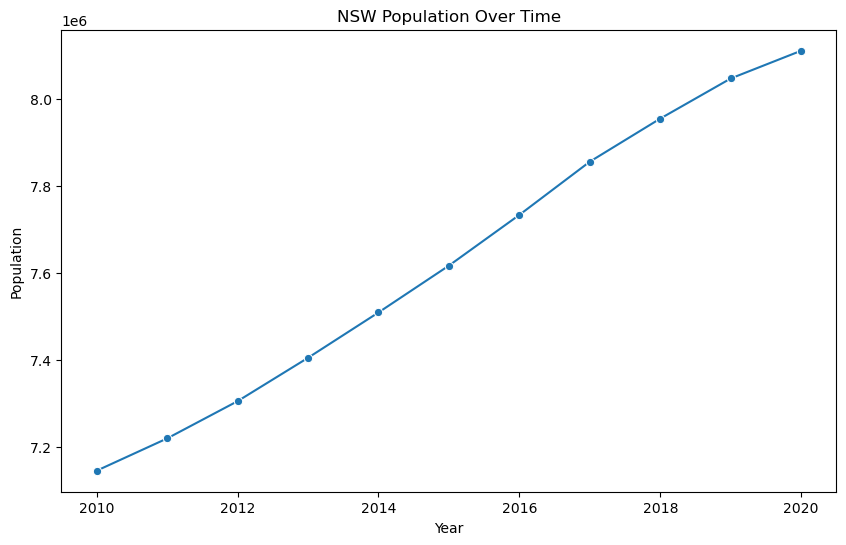

```python
# Plotting a line graph to visualize population over time
plt.figure(figsize=(10, 6))
sns.lineplot(
    x="Year",
    y="Population",
    data=df_pop[(df_pop["Year"] >= 2010) & (df_pop["Year"] < 2021)],
    marker="o",
)
plt.title("NSW Population Over Time")
plt.xlabel("Year")
plt.ylabel("Population")
plt.show()
```

```python
df_pop["Growth_Rate"] = df_pop["Population"].pct_change() * 100
```

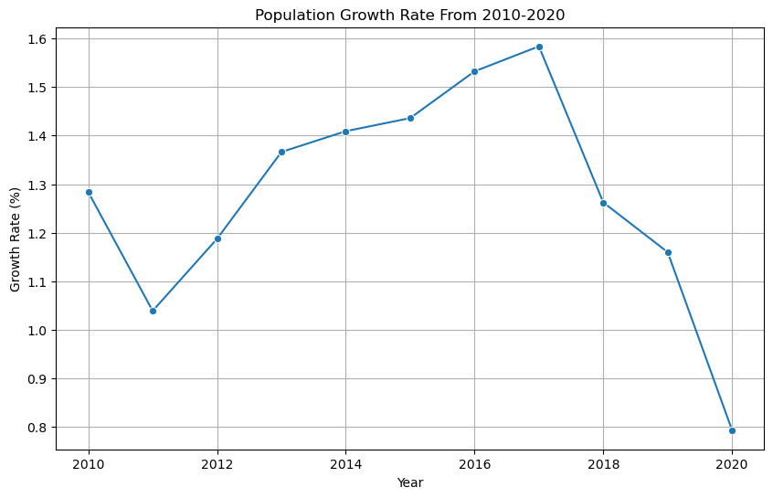

```python
plt.figure(figsize=(10, 6))
sns.lineplot(
    x="Year",
    y="Growth_Rate",
    data=df_pop[(df_pop["Year"] >= 2010) & (df_pop["Year"] < 2021)],
    marker="o",
)
plt.title("Population Growth Rate From 2010-2020")
plt.xlabel("Year")
plt.ylabel("Growth Rate (%)")
plt.grid(True)
plt.show()
```

```python
df_pop = df_pop[df_pop["Year"] >= 2010]
df_pop.head()
```

|  | Year | Population | Growth_Rate |
| --- | --- | --- | --- |
| 109 | 2010 | 7144292.0 | 1.283529 |
| 110 | 2011 | 7218529.0 | 1.039109 |
| 111 | 2012 | 7304244.0 | 1.187430 |
| 112 | 2013 | 7404032.0 | 1.366165 |
| 113 | 2014 | 7508353.0 | 1.408976 |

```python
df_pop_merge = df_merge.merge(df_pop, left_on="year", right_on="Year", how="left")
```

```python
df_pop_merge.head(-1)
```

|  | datetime | demand | year | month | hour | dayofweek | temp | date | daily_avg_demand | daily_avg_temp | season | Year | Population | Growth_Rate |
| --- | --- | --- | --- | --- | --- | --- | --- | --- | --- | --- | --- | --- | --- | --- |
| 0 | 2010-01-01 00:00:00 | 8038.00 | 2010 | 1 | 0 | 4 | 23.1 | 2010-01-01 | 7801.352917 | 25.185417 | Summer | 2010 | 7144292.0 | 1.283529 |
| 1 | 2010-01-01 00:30:00 | 7809.31 | 2010 | 1 | 0 | 4 | 22.9 | 2010-01-01 | 7801.352917 | 25.185417 | Summer | 2010 | 7144292.0 | 1.283529 |
| 2 | 2010-01-01 01:00:00 | 7483.69 | 2010 | 1 | 1 | 4 | 22.6 | 2010-01-01 | 7801.352917 | 25.185417 | Summer | 2010 | 7144292.0 | 1.283529 |
| 3 | 2010-01-01 01:30:00 | 7117.23 | 2010 | 1 | 1 | 4 | 22.5 | 2010-01-01 | 7801.352917 | 25.185417 | Summer | 2010 | 7144292.0 | 1.283529 |
| 4 | 2010-01-01 02:00:00 | 6812.03 | 2010 | 1 | 2 | 4 | 22.5 | 2010-01-01 | 7801.352917 | 25.185417 | Summer | 2010 | 7144292.0 | 1.283529 |
| ... | ... | ... | ... | ... | ... | ... | ... | ... | ... | ... | ... | ... | ... | ... |
| 196520 | 2021-03-17 21:30:00 | 7503.12 | 2021 | 3 | 21 | 2 | 19.7 | 2021-03-17 | 7428.187917 | 19.647917 | Autumn | 2021 | 8097062.0 | -0.167040 |
| 196521 | 2021-03-17 22:00:00 | 7419.77 | 2021 | 3 | 22 | 2 | 19.7 | 2021-03-17 | 7428.187917 | 19.647917 | Autumn | 2021 | 8097062.0 | -0.167040 |
| 196522 | 2021-03-17 22:30:00 | 7417.91 | 2021 | 3 | 22 | 2 | 19.5 | 2021-03-17 | 7428.187917 | 19.647917 | Autumn | 2021 | 8097062.0 | -0.167040 |
| 196523 | 2021-03-17 23:00:00 | 7287.32 | 2021 | 3 | 23 | 2 | 19.1 | 2021-03-17 | 7428.187917 | 19.647917 | Autumn | 2021 | 8097062.0 | -0.167040 |
| 196524 | 2021-03-17 23:30:00 | 7172.39 | 2021 | 3 | 23 | 2 | 18.8 | 2021-03-17 | 7428.187917 | 19.647917 | Autumn | 2021 | 8097062.0 | -0.167040 |

196525 rows × 14 columns

```python
df_pop_merge.drop(columns=["Year"], inplace=True)
df_pop_merge.head(-1)
```

|  | datetime | demand | year | month | hour | dayofweek | temp | date | daily_avg_demand | daily_avg_temp | season | Population | Growth_Rate |
| --- | --- | --- | --- | --- | --- | --- | --- | --- | --- | --- | --- | --- | --- |
| 0 | 2010-01-01 00:00:00 | 8038.00 | 2010 | 1 | 0 | 4 | 23.1 | 2010-01-01 | 7801.352917 | 25.185417 | Summer | 7144292.0 | 1.283529 |
| 1 | 2010-01-01 00:30:00 | 7809.31 | 2010 | 1 | 0 | 4 | 22.9 | 2010-01-01 | 7801.352917 | 25.185417 | Summer | 7144292.0 | 1.283529 |
| 2 | 2010-01-01 01:00:00 | 7483.69 | 2010 | 1 | 1 | 4 | 22.6 | 2010-01-01 | 7801.352917 | 25.185417 | Summer | 7144292.0 | 1.283529 |
| 3 | 2010-01-01 01:30:00 | 7117.23 | 2010 | 1 | 1 | 4 | 22.5 | 2010-01-01 | 7801.352917 | 25.185417 | Summer | 7144292.0 | 1.283529 |
| 4 | 2010-01-01 02:00:00 | 6812.03 | 2010 | 1 | 2 | 4 | 22.5 | 2010-01-01 | 7801.352917 | 25.185417 | Summer | 7144292.0 | 1.283529 |
| ... | ... | ... | ... | ... | ... | ... | ... | ... | ... | ... | ... | ... | ... |
| 196520 | 2021-03-17 21:30:00 | 7503.12 | 2021 | 3 | 21 | 2 | 19.7 | 2021-03-17 | 7428.187917 | 19.647917 | Autumn | 8097062.0 | -0.167040 |
| 196521 | 2021-03-17 22:00:00 | 7419.77 | 2021 | 3 | 22 | 2 | 19.7 | 2021-03-17 | 7428.187917 | 19.647917 | Autumn | 8097062.0 | -0.167040 |
| 196522 | 2021-03-17 22:30:00 | 7417.91 | 2021 | 3 | 22 | 2 | 19.5 | 2021-03-17 | 7428.187917 | 19.647917 | Autumn | 8097062.0 | -0.167040 |
| 196523 | 2021-03-17 23:00:00 | 7287.32 | 2021 | 3 | 23 | 2 | 19.1 | 2021-03-17 | 7428.187917 | 19.647917 | Autumn | 8097062.0 | -0.167040 |
| 196524 | 2021-03-17 23:30:00 | 7172.39 | 2021 | 3 | 23 | 2 | 18.8 | 2021-03-17 | 7428.187917 | 19.647917 | Autumn | 8097062.0 | -0.167040 |

196525 rows × 13 columns

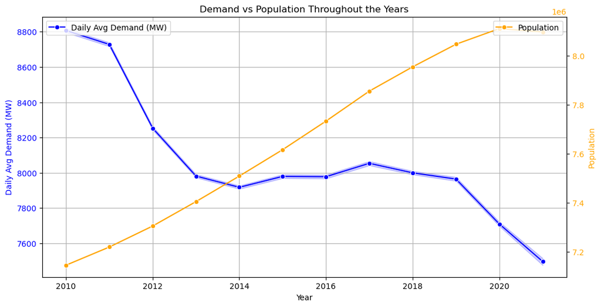

```python
fig, ax1 = plt.subplots(figsize=(12, 6))

# Plotting daily average demand on the first y-axis
sns.lineplot(
    x="year",
    y="daily_avg_demand",
    data=df_pop_merge,
    marker="o",
    label="Daily Avg Demand (MW)",
    color="blue",
    ax=ax1,
)
ax1.set_ylabel("Daily Avg Demand (MW)", color="blue")
ax1.tick_params(axis="y", labelcolor="blue")

# Creating a second y-axis for the population
ax2 = ax1.twinx()
sns.lineplot(
    x="year",
    y="Population",
    data=df_pop_merge,
    marker="o",
    label="Population",
    color="orange",
    ax=ax2,
)
ax2.set_ylabel("Population", color="orange")
ax2.tick_params(axis="y", labelcolor="orange")

# Adding labels and title
plt.title("Demand vs Population Throughout the Years")
ax1.set_xlabel("Year")
ax1.grid()

# Adding a legend
ax1.legend(loc="upper left")
ax2.legend(loc="upper right")

# Show the plot
plt.show()
```

Seems like there is a negative correlation between demand and population, further investigation using correlation heatmap is needed.

```python
df_ML = pd.read_csv("../data/NSW/data_for_ml.csv")
df_ML.head()
```

|  | Date | mean_humidity | SOI | SST_DIFF | mean_solar_radiation | mean_temp | mean_wind_direction | mean_windspeed | rainfall | Population | TOTALDEMAND | DAYOFWEEK | DAYOFYEAR |
| --- | --- | --- | --- | --- | --- | --- | --- | --- | --- | --- | --- | --- | --- |
| 0 | 2010-01-01 | 71.304348 | 11.17 | 1.59 | 187.700000 | 23.836522 | 231.727174 | 2.591304 | 0.6 | 7.110753e+06 | 7801.352917 | 4 | 1 |
| 1 | 2010-01-02 | 76.874167 | 8.91 | 1.59 | 213.191667 | 23.453333 | 178.430556 | 1.696528 | 0.3 | 7.111051e+06 | 8017.459792 | 5 | 2 |
| 2 | 2010-01-03 | 85.810000 | 4.48 | 1.59 | 73.622917 | 17.603333 | 147.411458 | 2.223264 | 12.6 | 7.111350e+06 | 7399.899583 | 6 | 3 |
| 3 | 2010-01-04 | 80.723333 | 14.09 | 1.55 | 125.110417 | 18.863333 | 107.968056 | 1.743403 | 1.0 | 7.111648e+06 | 8241.720208 | 0 | 4 |
| 4 | 2010-01-05 | 67.842500 | 11.69 | 1.55 | 300.906250 | 22.985000 | 113.673611 | 1.587500 | 0.0 | 7.111946e+06 | 8827.813125 | 1 | 5 |

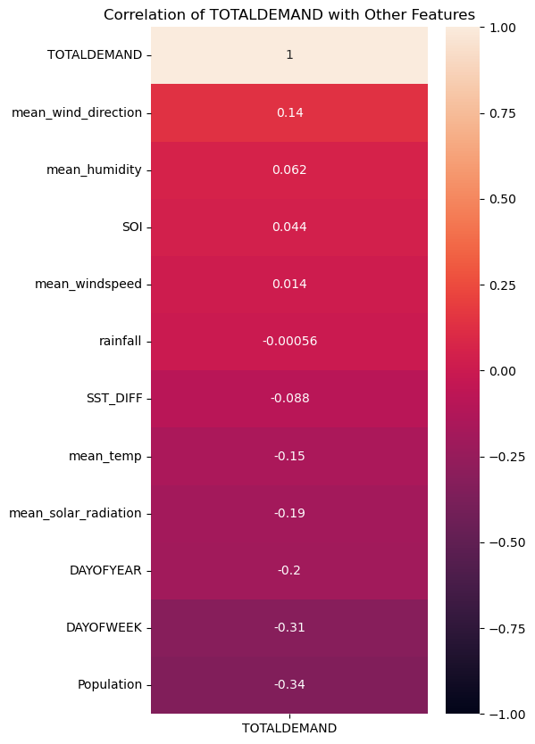

```python
corr_matrix = df_ML.corr()

# Filter the correlations to only include the TOTALDEMAND column
totaldemand_corr = corr_matrix[["TOTALDEMAND"]].sort_values(
    by="TOTALDEMAND", ascending=False
)

# Plot the heatmap for TOTALDEMAND correlations
plt.figure(figsize=(5, 10))
sns.heatmap(totaldemand_corr, annot=True, vmin=-1, vmax=1)
plt.title("Correlation of TOTALDEMAND with Other Features")
plt.show()
```

# Analysis and Results

### A First Model

Linear regression model: $$ Y_i = \beta_0 + \beta_1 x_{1i} + \cdots + \beta_p x_{pi} + \epsilon_i $$

# Discussion

# Conclusion and Further Issues

[figure not shown]

# Refereneces

Afzal, S. et al. (2023) ‘Building energy consumption prediction using multilayer perceptron neural network-assisted models; comparison of different optimization algorithms’, Energy, 282. Available at: https://doi.org/10.1016/j.energy.2023.128446.

AIML maintainers (no date) What are the advantages and disadvantages of Random Forest?, AIML.com.

Albuquerque, P.C., Cajueiro, D.O. and Rossi, M.D.C. (2022) ‘Machine learning models for forecasting power electricity consumption using a high dimensional dataset’, Expert Systems with Applications, 187. Available at: https://doi.org/10.1016/j.eswa.2021.115917.

Australian Energy Market Operator (2022) Forecasting Approach-Electricity Demand Forecasting Methodology.

Australian Photovoltaic Institute (2024) State Performance, APVI.

Bedi, J. and Toshniwal, D. (2019) ‘Deep learning framework to forecast electricity demand’, Applied Energy, 238, pp. 1312–1326. Available at: https://doi.org/10.1016/j.apenergy.2019.01.113.

Bilgili, M. and Pinar, E. (2023) ‘Gross electricity consumption forecasting using LSTM and SARIMA approaches: A case study of Türkiye’, Energy, 284. Available at: https://doi.org/10.1016/j.energy.2023.128575.

Chreng, K., Lee, H.S. and Tuy, S. (2022) ‘A Hybrid Model for Electricity Demand Forecast Using Improved Ensemble Empirical Mode Decomposition and Recurrent Neural Networks with ERA5 Climate Variables’, Energies, 15(19). Available at: https://doi.org/10.3390/en15197434.

Eskeland, G.S. and Mideksa, T.K. (2010) ‘Electricity demand in a changing climate’, Mitigation and Adaptation Strategies for Global Change, 15(8), pp. 877–897. Available at: https://doi.org/10.1007/s11027-010-9246-x.

Fan, H., Macgill, I.F. and Sproul, A.B. (2015) Statistical analysis of driving factors of residential energy demand in the greater Sydney region, Australia. Available at: https://doi.org/http://dx.doi.org/10.1016/j.enbuild.2015.07.030.

Fan, H., MacGill, I.F. and Sproul, A.B. (2017) ‘Statistical analysis of drivers of residential peak electricity demand’, Energy and Buildings, 141, pp. 205–217. Available at: https://doi.org/10.1016/j.enbuild.2017.02.030.

Fan, S. and Hyndman, R.J. (2010) ‘Short-term load forecasting based on a semi-parametric additive model’, IEEE Transactions on Power Systems. Melbourne. Available at: chrome-extension://efaidnbmnnnibpcajpcglclefindmkaj/https://robjhyndman.com/papers/2010STLF-FinalR1.pdf (Accessed: 17 September 2024).

Fattah, J. et al. (2018) ‘Forecasting of demand using ARIMA model’, International Journal of Engineering Business Management, 10. Available at: https://doi.org/10.1177/1847979018808673.

International Energy Agency (2023) Keeping cool in a hotter world is using more energy, making efficiency more important than ever, IEA.

Koprinska, I., Wu, D. and Wang, Z. (2018) ‘Convolutional Neural Networks for Energy Time Series Forecasting’, in 2018 International Joint Conference on Neural Networks (IJCNN). IEEE, pp. 1–8. Available at: https://doi.org/10.1109/IJCNN.2018.8489399.

Kumar Dubey, A. et al. (2021) ‘Study and analysis of SARIMA and LSTM in forecasting time series data’, Sustainable Energy Technologies and Assessments, 47. Available at: https://doi.org/10.1016/j.seta.2021.101474.

Leung, A. (2022) ‘A Multivariate Model for Electricity Demand using Facebook Prophet’, TowardsDataScience [Preprint].

Liu, Y. et al. (2023) ‘Enhanced multi-year predictability after El Niño and La Niña events’, Nature Communications, 14(1). Available at: https://doi.org/10.1038/s41467-023-42113-9.

Mahjoub, S. et al. (2022) ‘Predicting Energy Consumption Using LSTM, Multi-Layer GRU and Drop-GRU Neural Networks’, Sensors, 22(11). Available at: https://doi.org/10.3390/s22114062.

Mavuduru, A. (2020) Why XGBoost Can’t Solve All Your Problems, TowardsDataScience. Mfetoum, I.M. et al. (2024) ‘A multilayer perceptron neural network approach for optimizing solar irradiance forecasting in Central Africa with meteorological insights’, Scientific Reports, 14(1). Available at: https://doi.org/10.1038/s41598-024-54181-y.

Nooruldeen, O. et al. (2023) ‘Strategies for predictive power: Machine learning models in city-scale load forecasting’, e-Prime - Advances in Electrical Engineering, Electronics and Energy, 6. Available at: https://doi.org/10.1016/j.prime.2023.100392.

Porteiro, R., Hernández-Callejo, L. and Nesmachnow, S. (2022) ‘Electricity demand forecasting in industrial and residential facilities using ensemble machine learning’, Revista Facultad de Ingeniería, Universidad de Antioquia [Preprint]. Available at: https://doi.org/https://www.doi. org/10.17533/udea. redin.20200584.

Qureshi, M., Arbab, M.A. and Rehman, S. ur (2024) ‘Deep learning-based forecasting of electricity consumption’, Scientific Reports, 14(1). Available at: https://doi.org/10.1038/s41598-024-56602-4.

Scikit Learn Maintainers (2024a) Compare Stochastic learning strategies for MLPClassifier, Scikit Learn Documentation.

Scikit Learn Maintainers (2024b) MLPClassifier, Scikit Learn Documentation.

Thompson, B. (2019) A limitation of Random Forest Regression, Towards Data Science. Vijendar Reddy, G. et al. (2023) ‘Electricity Consumption Prediction Using Machine Learning’, in E3S Web of Conferences. EDP Sciences. Available at: https://doi.org/10.1051/e3sconf/202339101048.

Vu, D.H., Muttaqi, K.M. and Agalgaonkar, A.P. (2015) ‘A variance inflation factor and backward elimination based robust regression model for forecasting monthly electricity demand using climatic variables’, Applied Energy, 140, pp. 385–394. Available at: https://doi.org/10.1016/j.apenergy.2014.12.011.

Zhou, H.S. et al. (2021) ‘A case study on the behaviour of residential battery energy storage systems during network demand peaks’, Renewable Energy, 180, pp. 712–724. Available at: https://doi.org/10.1016/j.renene.2021.08.107.

# Appendix